# ML Final Project

Ellington Chen

11/22/2021

The main purpose of our analysis is to predict who is more likely to default on their credit card loans, so that the bank may be able to prevent the loss by providing the customer with alternative options.

```r
library(dplyr)
library(caret)
library(reshape)
# Read in the data
application_record <- read.csv('application_record.csv', stringsAsFactors = TRUE)
credit_record <- read.csv('credit_record.csv', stringsAsFactors = TRUE)
```

```r
# Check the head and tail
head(application_record)
```

```
##        ID CODE_GENDER FLAG_OWN_CAR FLAG_OWN_REALTY CNT_CHILDREN
## 1 5008804           M            Y               Y            0
## 2 5008805           M            Y               Y            0
## 3 5008806           M            Y               Y            0
## 4 5008808           F            N               Y            0
## 5 5008809           F            N               Y            0
## 6 5008810           F            N               Y            0
##   AMT_INCOME_TOTAL     NAME_INCOME_TYPE           NAME_EDUCATION_TYPE
## 1           427500              Working              Higher education
## 2           427500              Working              Higher education
## 3           112500              Working Secondary / secondary special
## 4           270000 Commercial associate Secondary / secondary special
## 5           270000 Commercial associate Secondary / secondary special
## 6           270000 Commercial associate Secondary / secondary special
##     NAME_FAMILY_STATUS NAME_HOUSING_TYPE DAYS_BIRTH DAYS_EMPLOYED FLAG_MOBIL
## 1       Civil marriage  Rented apartment     -12005         -4542          1
## 2       Civil marriage  Rented apartment     -12005         -4542          1
## 3              Married House / apartment     -21474         -1134          1
## 4 Single / not married House / apartment     -19110         -3051          1
## 5 Single / not married House / apartment     -19110         -3051          1
## 6 Single / not married House / apartment     -19110         -3051          1
##   FLAG_WORK_PHONE FLAG_PHONE FLAG_EMAIL OCCUPATION_TYPE CNT_FAM_MEMBERS
## 1               1          0          0                               2
## 2               1          0          0                               2
## 3               0          0          0  Security staff               2
## 4               0          1          1     Sales staff               1
## 5               0          1          1     Sales staff               1
## 6               0          1          1     Sales staff               1
```

```r
tail(application_record)
```

```
##             ID CODE_GENDER FLAG_OWN_CAR FLAG_OWN_REALTY CNT_CHILDREN
## 438552 6840102           F            N               Y            0
## 438553 6840104           M            N               Y            0
## 438554 6840222           F            N               N            0
## 438555 6841878           F            N               N            0
## 438556 6842765           F            N               Y            0
## 438557 6842885           F            N               Y            0
##        AMT_INCOME_TOTAL     NAME_INCOME_TYPE           NAME_EDUCATION_TYPE
## 438552           135000            Pensioner Secondary / secondary special
## 438553           135000            Pensioner Secondary / secondary special
## 438554           103500              Working Secondary / secondary special
## 438555            54000 Commercial associate              Higher education
## 438556            72000            Pensioner Secondary / secondary special
## 438557           121500              Working Secondary / secondary special
##          NAME_FAMILY_STATUS NAME_HOUSING_TYPE DAYS_BIRTH DAYS_EMPLOYED
```

[output cut: 20 more lines]

```r
head(credit_record)
```

```
##        ID MONTHS_BALANCE STATUS
## 1 5001711              0      X
## 2 5001711             -1      0
## 3 5001711             -2      0
## 4 5001711             -3      0
## 5 5001712              0      C
## 6 5001712             -1      C
```

```r
tail(credit_record)
```

```
##              ID MONTHS_BALANCE STATUS
## 1048570 5150487            -24      C
## 1048571 5150487            -25      C
## 1048572 5150487            -26      C
## 1048573 5150487            -27      C
## 1048574 5150487            -28      C
## 1048575 5150487            -29      C
```

```r
# Check the dimension
dim(application_record)
```

```
## [1] 438557     18
```

```r
dim(credit_record)
```

```
## [1] 1048575       3
```

```r
# Do a summary on the data
summary(application_record)
```

```
##        ID          CODE_GENDER FLAG_OWN_CAR FLAG_OWN_REALTY  CNT_CHILDREN
##  Min.   :5008804   F:294440    N:275459     N:134483        Min.   : 0.0000
##  1st Qu.:5609375   M:144117    Y:163098     Y:304074        1st Qu.: 0.0000
##  Median :6047745                                            Median : 0.0000
##  Mean   :6022176                                            Mean   : 0.4274
##  3rd Qu.:6456971                                            3rd Qu.: 1.0000
##  Max.   :7999952                                            Max.   :19.0000
##
##  AMT_INCOME_TOTAL              NAME_INCOME_TYPE
##  Min.   :  26100   Commercial associate:100757
##  1st Qu.: 121500   Pensioner           : 75493
##  Median : 160780   State servant       : 36186
##  Mean   : 187524   Student             :    17
##  3rd Qu.: 225000   Working             :226104
##  Max.   :6750000
##
##                     NAME_EDUCATION_TYPE            NAME_FAMILY_STATUS
##  Academic degree              :   312   Civil marriage      : 36532
##  Higher education             :117522   Married             :299828
##  Incomplete higher            : 14851   Separated           : 27251
##  Lower secondary              :  4051   Single / not married: 55271
##  Secondary / secondary special:301821   Widow               : 19675
##
##
##            NAME_HOUSING_TYPE    DAYS_BIRTH     DAYS_EMPLOYED      FLAG_MOBIL
##  Co-op apartment    :  1539   Min.   :-25201   Min.   :-17531   Min.   :1
##  House / apartment  :393831   1st Qu.:-19483   1st Qu.: -3103   1st Qu.:1
##  Municipal apartment: 14214   Median :-15630   Median : -1467   Median :1
##  Office apartment   :  3922   Mean   :-15998   Mean   : 60564   Mean   :1
##  Rented apartment   :  5974   3rd Qu.:-12514   3rd Qu.:  -371   3rd Qu.:1
##  With parents       : 19077   Max.   : -7489   Max.   :365243   Max.   :1
##
##  FLAG_WORK_PHONE    FLAG_PHONE       FLAG_EMAIL        OCCUPATION_TYPE
##  Min.   :0.0000   Min.   :0.0000   Min.   :0.0000              :134203
##  1st Qu.:0.0000   1st Qu.:0.0000   1st Qu.:0.0000   Laborers   : 78240
##  Median :0.0000   Median :0.0000   Median :0.0000   Core staff : 43007
##  Mean   :0.2061   Mean   :0.2878   Mean   :0.1082   Sales staff: 41098
##  3rd Qu.:0.0000   3rd Qu.:1.0000   3rd Qu.:0.0000   Managers   : 35487
##  Max.   :1.0000   Max.   :1.0000   Max.   :1.0000   Drivers    : 26090
##                                                     (Other)    : 80432
##  CNT_FAM_MEMBERS
##  Min.   : 1.000
##  1st Qu.: 2.000
##  Median : 2.000
##  Mean   : 2.194
##  3rd Qu.: 3.000
##  Max.   :20.000
##
```

```r
summary(credit_record)
```

```
##        ID          MONTHS_BALANCE       STATUS
##  Min.   :5001711   Min.   :-60.00   C      :442031
##  1st Qu.:5023644   1st Qu.:-29.00   0      :383120
##  Median :5062104   Median :-17.00   X      :209230
##  Mean   :5068286   Mean   :-19.14   1      : 11090
##  3rd Qu.:5113856   3rd Qu.: -7.00   5      :  1693
##  Max.   :5150487   Max.   :  0.00   2      :   868
##                                     (Other):   543
```

So, the variables we have are:  
**ID** - Client number  
**CODE_GENDER** - Gender  
**FLAG_OWN_CAR** - Is there a car  
**FLAG_OWN_REALTY** - Is there a property  
**CNT_CHILDREN** - Number of children  
**AMT_INCOME_TOTAL** - Annual income  
**NAME_INCOME_TYPE** - Income category  
**NAME_EDUCATION_TYPE** - Education level  
**NAME_FAMILY_STATUS** - Marital status  
**NAME_HOUSING_TYPE** - Way of living  
**DAYS_BIRTH** - Birthday - Count backwards from current day (0), -1 means yesterday  
**DAYS_EMPLOYED** - Start date of employment - Count backwards from current day(0). If positive, it means the person currently unemployed.  
**FLAG_MOBIL** - Is there a mobile phone  
**FLAG_WORK_PHONE** - Is there a work phone  
**FLAG_PHONE** - Is there a phone  
**FLAG_EMAIL** - Is there an email  
**OCCUPATION_TYPE** - Occupation  
**CNT_FAM_MEMBERS** - Family size  
**MONTHS_BALANCE** - Record month - The month of the extracted data is the starting point, backwards, 0 is the current month, -1 is the previous month, and so on  
**STATUS** - Status - 0: 1-29 days past due 1: 30-59 days past due 2: 60-89 days overdue 3: 90-119 days overdue 4: 120-149 days overdue 5: Overdue or bad debts, write-offs for more than 150 days C: paid off that month X: No loan for the month  
However, we still have three problems to solve:  
1. We need to merge two data sets  
2. We haven’t create our dependent variable  
3. Each user had several different loans, the overdue status for each of their loans is also different.

```r
# Generally, users in risk should be in 3%, thus we choose users who overdue for more than 60 days as target risky users. Those samples are marked as '1', else are '0'.

# For loans that overdue by more than 60 days, we mark them as '1', else are '0'
credit_record[,'target'] <- 0
credit_record[credit_record[, 'STATUS'] == 2, 'target'] <- 1
credit_record[credit_record[, 'STATUS'] == 3, 'target'] <- 1
credit_record[credit_record[, 'STATUS'] == 4, 'target'] <- 1
credit_record[credit_record[, 'STATUS'] == 5, 'target'] <- 1

# We group by ID to see how many overdue loans(> 60 days) does each user have
credit_record <- credit_record %>%
                 group_by(ID) %>%
                 summarise(count = sum(target == 1))

# For those who have at least one overdue loans(> 60 days) we mark them as '1'(target risky users)
credit_record[credit_record$count > 0, 'count'] <- 1
```

```r
# Then we merge two data sets
total_data <- merge(x=application_record,y=credit_record,by="ID",all=FALSE)

# Rename our dependent variable as 'target'
names(total_data)[names(total_data) == "count"] <- "target"
```

```r
# Check our final data
head(total_data)
```

```
##        ID CODE_GENDER FLAG_OWN_CAR FLAG_OWN_REALTY CNT_CHILDREN
## 1 5008804           M            Y               Y            0
## 2 5008805           M            Y               Y            0
## 3 5008806           M            Y               Y            0
## 4 5008808           F            N               Y            0
## 5 5008809           F            N               Y            0
## 6 5008810           F            N               Y            0
##   AMT_INCOME_TOTAL     NAME_INCOME_TYPE           NAME_EDUCATION_TYPE
## 1           427500              Working              Higher education
## 2           427500              Working              Higher education
## 3           112500              Working Secondary / secondary special
## 4           270000 Commercial associate Secondary / secondary special
## 5           270000 Commercial associate Secondary / secondary special
## 6           270000 Commercial associate Secondary / secondary special
##     NAME_FAMILY_STATUS NAME_HOUSING_TYPE DAYS_BIRTH DAYS_EMPLOYED FLAG_MOBIL
## 1       Civil marriage  Rented apartment     -12005         -4542          1
## 2       Civil marriage  Rented apartment     -12005         -4542          1
## 3              Married House / apartment     -21474         -1134          1
## 4 Single / not married House / apartment     -19110         -3051          1
## 5 Single / not married House / apartment     -19110         -3051          1
## 6 Single / not married House / apartment     -19110         -3051          1
##   FLAG_WORK_PHONE FLAG_PHONE FLAG_EMAIL OCCUPATION_TYPE CNT_FAM_MEMBERS target
## 1               1          0          0                               2      0
## 2               1          0          0                               2      0
## 3               0          0          0  Security staff               2      0
## 4               0          1          1     Sales staff               1      0
## 5               0          1          1     Sales staff               1      0
## 6               0          1          1     Sales staff               1      0
```

```r
tail(total_data)
```

```
##            ID CODE_GENDER FLAG_OWN_CAR FLAG_OWN_REALTY CNT_CHILDREN
## 36452 5150481           F            Y               Y            1
## 36453 5150482           F            Y               Y            1
## 36454 5150483           F            Y               Y            1
## 36455 5150484           F            Y               Y            1
## 36456 5150485           F            Y               Y            1
## 36457 5150487           M            Y               N            0
##       AMT_INCOME_TOTAL NAME_INCOME_TYPE           NAME_EDUCATION_TYPE
## 36452           157500          Working Secondary / secondary special
## 36453           157500          Working Secondary / secondary special
## 36454           157500          Working Secondary / secondary special
## 36455           157500          Working Secondary / secondary special
## 36456           157500          Working Secondary / secondary special
## 36457           202500          Working Secondary / secondary special
##       NAME_FAMILY_STATUS NAME_HOUSING_TYPE DAYS_BIRTH DAYS_EMPLOYED FLAG_MOBIL
```

[output cut: 20 more lines]

```r
dim(total_data)
```

```
## [1] 36457    19
```

```r
summary(total_data)
```

```
##        ID          CODE_GENDER FLAG_OWN_CAR FLAG_OWN_REALTY  CNT_CHILDREN
##  Min.   :5008804   F:24430     N:22614      N:11951         Min.   : 0.0000
##  1st Qu.:5042028   M:12027     Y:13843      Y:24506         1st Qu.: 0.0000
##  Median :5074614                                            Median : 0.0000
##  Mean   :5078227                                            Mean   : 0.4303
##  3rd Qu.:5115396                                            3rd Qu.: 1.0000
##  Max.   :5150487                                            Max.   :19.0000
##
##  AMT_INCOME_TOTAL              NAME_INCOME_TYPE
##  Min.   :  27000   Commercial associate: 8490
##  1st Qu.: 121500   Pensioner           : 6152
##  Median : 157500   State servant       : 2985
##  Mean   : 186686   Student             :   11
##  3rd Qu.: 225000   Working             :18819
##  Max.   :1575000
##
##                     NAME_EDUCATION_TYPE            NAME_FAMILY_STATUS
##  Academic degree              :   32    Civil marriage      : 2945
##  Higher education             : 9864    Married             :25048
##  Incomplete higher            : 1410    Separated           : 2103
##  Lower secondary              :  374    Single / not married: 4829
##  Secondary / secondary special:24777    Widow               : 1532
##
##
##            NAME_HOUSING_TYPE   DAYS_BIRTH     DAYS_EMPLOYED      FLAG_MOBIL
##  Co-op apartment    :  168   Min.   :-25152   Min.   :-15713   Min.   :1
##  House / apartment  :32548   1st Qu.:-19438   1st Qu.: -3153   1st Qu.:1
##  Municipal apartment: 1128   Median :-15563   Median : -1552   Median :1
##  Office apartment   :  262   Mean   :-15975   Mean   : 59263   Mean   :1
##  Rented apartment   :  575   3rd Qu.:-12462   3rd Qu.:  -408   3rd Qu.:1
##  With parents       : 1776   Max.   : -7489   Max.   :365243   Max.   :1
##
##  FLAG_WORK_PHONE    FLAG_PHONE       FLAG_EMAIL         OCCUPATION_TYPE
##  Min.   :0.0000   Min.   :0.0000   Min.   :0.00000              :11323
##  1st Qu.:0.0000   1st Qu.:0.0000   1st Qu.:0.00000   Laborers   : 6211
##  Median :0.0000   Median :0.0000   Median :0.00000   Core staff : 3591
##  Mean   :0.2255   Mean   :0.2948   Mean   :0.08972   Sales staff: 3485
##  3rd Qu.:0.0000   3rd Qu.:1.0000   3rd Qu.:0.00000   Managers   : 3012
##  Max.   :1.0000   Max.   :1.0000   Max.   :1.00000   Drivers    : 2138
##                                                      (Other)    : 6697
##  CNT_FAM_MEMBERS      target
##  Min.   : 1.000   Min.   :0.0000
##  1st Qu.: 2.000   1st Qu.:0.0000
##  Median : 2.000   Median :0.0000
##  Mean   : 2.198   Mean   :0.0169
##  3rd Qu.: 3.000   3rd Qu.:0.0000
##  Max.   :20.000   Max.   :1.0000
##
```

```r
# Modify some of the variables
# Change the scale of annual income to 1000
total_data$AMT_INCOME_TOTAL <- total_data$AMT_INCOME_TOTAL / 1000

# Change DAYS_BIRTH to AGE
total_data$DAYS_BIRTH <- (-total_data$DAYS_BIRTH) %/% 365
names(total_data)[names(total_data) == "DAYS_BIRTH"] <- "AGE"

# Change DAYS_EMPLOYED to WORKING_YEARS
total_data$DAYS_EMPLOYED <- (-total_data$DAYS_EMPLOYED) %/% 365
names(total_data)[names(total_data) == "DAYS_EMPLOYED"] <- "WORKING_YEARS"
# For currently unemployed people, set their working years as mean working years
mean_working_years <- round(mean(total_data[total_data$WORKING_YEARS > 0, 'WORKING_YEARS']), 0)
total_data[total_data$WORKING_YEARS < 0, 'WORKING_YEARS'] <- mean_working_years
```

After modification:  
**AMT_INCOME_TOTAL** - Annual income in thousands  
**AGE** - User’s age  
**WORKING_YEARS** - User’s working years

```r
# Data Partition
set.seed(12345)
total_data <- total_data[,-c(1,13)] # delete ID and FLAG_MOBIL
total_data$FLAG_WORK_PHONE <- as.factor(total_data$FLAG_WORK_PHONE)
total_data$FLAG_PHONE <- as.factor(total_data$FLAG_PHONE)
total_data$FLAG_EMAIL <- as.factor(total_data$FLAG_EMAIL)
total_data$target <- as.factor(total_data$target)
indices <- createDataPartition(1:nrow(total_data), p = 0.8, list = FALSE)
train_data <- total_data[indices,]
test_data <- total_data[-indices,]
```

```r
# Check missing training data
sum(is.na(train_data))
```

```
## [1] 0
```

```r
# Check missing test data
sum(is.na(test_data))
```

```
## [1] 0
```

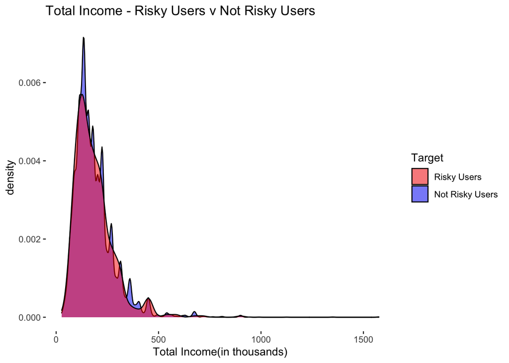

```r
# Do densities
plot_dat <- total_data
plot_dat$target <- as.factor(total_data$target)
g_1 <- ggplot(plot_dat, aes(x = AMT_INCOME_TOTAL, fill = target)) +
  geom_density(alpha = 0.5) +
    theme_set(theme_bw(base_size = 10) ) +
  theme(panel.grid.major = element_blank(),
        panel.grid.minor = element_blank(),
        panel.border = element_blank(),
        panel.background = element_blank()) +
  labs(x = "Total Income(in thousands)", title = "Total Income - Risky Users v Not Risky Users",
       fill = "Target") +
  scale_fill_manual(values = c("1" = "red", "0" = "blue"),
                    labels = c("1" = "Risky Users", "0" = "Not Risky Users"))
g_1
```

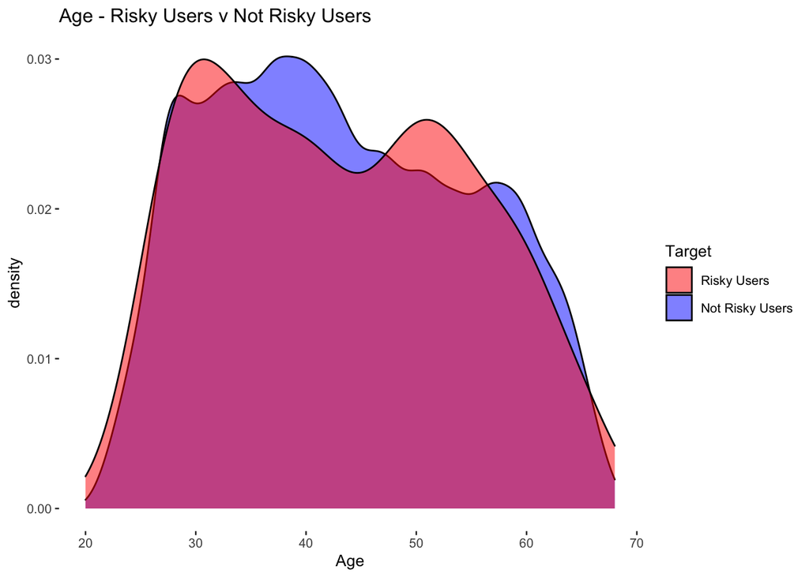

```r
# Do densities
g_2 <- ggplot(plot_dat, aes(x = AGE, fill = target)) +
  geom_density(alpha = 0.5) +
    theme_set(theme_bw(base_size = 10) ) +
  theme(panel.grid.major = element_blank(),
        panel.grid.minor = element_blank(),
        panel.border = element_blank(),
        panel.background = element_blank()) +
  labs(x = "Age", title = "Age - Risky Users v Not Risky Users",
       fill = "Target") +
  scale_fill_manual(values = c("1" = "red", "0" = "blue"),
                    labels = c("1" = "Risky Users", "0" = "Not Risky Users"))
g_2
```

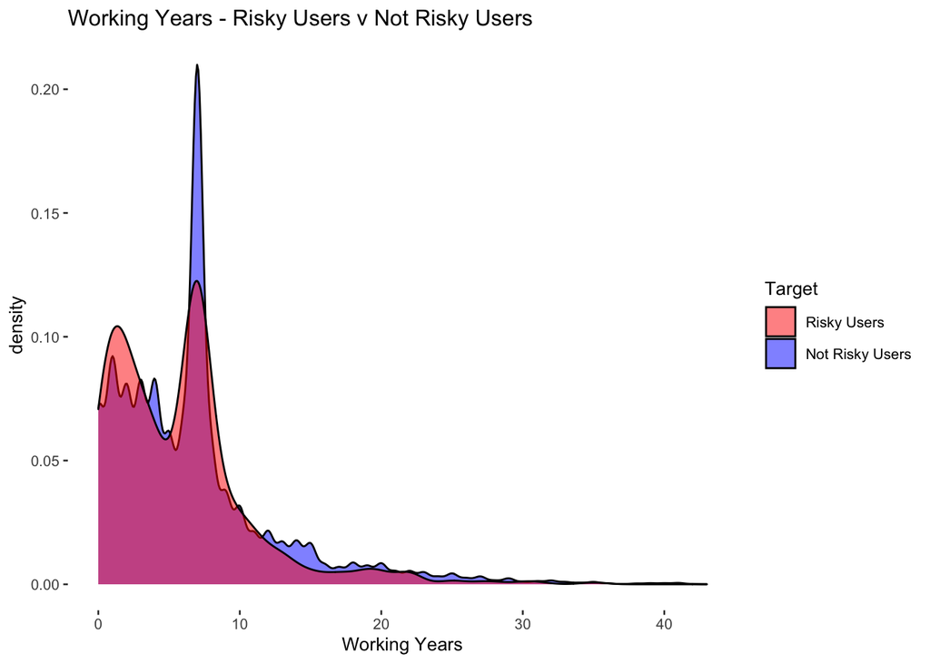

```r
g_3 <- ggplot(plot_dat, aes(x = WORKING_YEARS, fill = target)) +
  geom_density(alpha = 0.5) +
    theme_set(theme_bw(base_size = 10) ) +
  theme(panel.grid.major = element_blank(),
        panel.grid.minor = element_blank(),
        panel.border = element_blank(),
        panel.background = element_blank()) +
  labs(x = "Working Years", title = "Working Years - Risky Users v Not Risky Users",
       fill = "Target") +
  scale_fill_manual(values = c("1" = "red", "0" = "blue"),
                    labels = c("1" = "Risky Users", "0" = "Not Risky Users"))
g_3
```

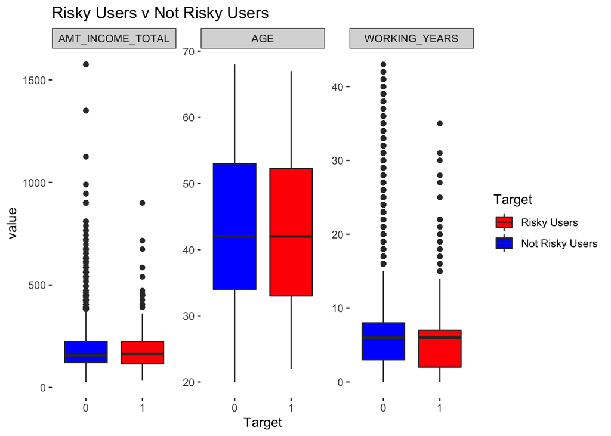

```r
# Use box plot to further explore the relationship
m_dat <- melt(plot_dat[,c('target','AMT_INCOME_TOTAL','AGE','WORKING_YEARS')], id.vars = "target")

g_4 <- ggplot(m_dat, aes( y = value, x = target, fill = target)) +
  geom_boxplot() +
  facet_wrap(~variable, scales = "free") +
    theme_bw() +
  theme(panel.grid.major = element_blank(),
        panel.grid.minor = element_blank(),
        panel.border = element_blank(),
        panel.background = element_blank()) +
  labs(x = "Target", title = "Risky Users v Not Risky Users",
       fill = "Target") +
  scale_fill_manual(values = c("1" = "red", "0" = "blue"),
                    labels = c("1" = "Risky Users", "0" = "Not Risky Users"))
g_4
```

```r
# Use ROSE to balance data
library(ROSE)
over_data <- ovun.sample(target~., data = train_data, method = 'over', N = 28663*2)$data
table(over_data$target)
```

```
##
##     0     1
## 28663 28663
```

Logistic Regression

```r
# Logistic Regression
lm_full <- glm(target~., family = 'binomial', data = over_data)

lm_full_pred <- predict(lm_full, newdata = test_data, type = 'response')

lm_full_acc <- confusionMatrix(factor(ifelse(lm_full_pred>0.5, '1', '0')), test_data$target, positive = '1')

lm_full_acc
```

```
## Confusion Matrix and Statistics
##
##           Reference
## Prediction    0    1
##          0 4256   50
##          1 2922   61
##
##                Accuracy : 0.5923
##                  95% CI : (0.5809, 0.6036)
##     No Information Rate : 0.9848
##     P-Value [Acc > NIR] : 1
##
##                   Kappa : 0.0104
##
##  Mcnemar's Test P-Value : <2e-16
##
##             Sensitivity : 0.549550
##             Specificity : 0.592923
##          Pos Pred Value : 0.020449
##          Neg Pred Value : 0.988388
##              Prevalence : 0.015228
##          Detection Rate : 0.008369
##    Detection Prevalence : 0.409247
##       Balanced Accuracy : 0.571236
##
##        'Positive' Class : 1
##
```

Lasso

```r
over_data_mod <- model.matrix(target~., data=over_data)[,-1]
test_data_mod <- model.matrix(target~., data=test_data)[,-1]
x_data <- as.data.frame(scale(over_data_mod)) # Scale dataset
x_data$target <- over_data$target
```

```r
library(glmnet)
```

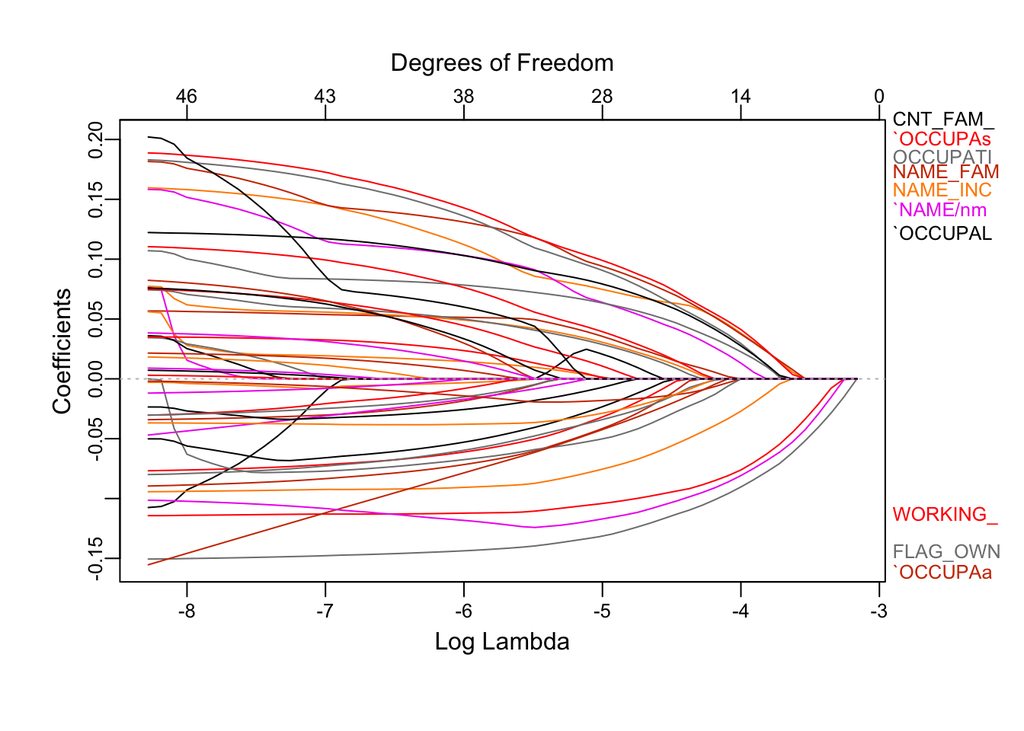

```r
library(plotmo)
# Create x variables
x_vars <- model.matrix(target ~.,
                       x_data)[,-1]
# Fit lasso model
lasso_fit <- glmnet(x = x_vars, # Set explantory variables
                    y = over_data$target, # Set response variable
                    alpha = 1, # Set alpha value
                    family = "binomial")
plot_glmnet(lasso_fit, # Plot lasso coefficients by lambda
            xvar = "lambda")
```

```r
# Print coefficients
coef(lasso_fit)
```

```
## 47 x 56 sparse Matrix of class "dgCMatrix"
```

```
##    [[ suppressing 56 column names 's0', 's1', 's2' ... ]]
```

[output not shown]

[output cut: 1289 more lines]

```
## OCCUPATION_TYPEDrivers                              0.1824875405  0.182989581
## `OCCUPATION_TYPEHigh skill tech staff`              0.1101082481  0.110434898
## `OCCUPATION_TYPEHR staff`                           0.0028916533  0.002999281
## `OCCUPATION_TYPEIT staff`                           0.0213624722  0.021518346
## OCCUPATION_TYPELaborers                             0.0816896055  0.082312175
## `OCCUPATION_TYPELow-skill Laborers`                 0.1219985163  0.122260358
## OCCUPATION_TYPEManagers                             0.0755320358  0.075874942
## `OCCUPATION_TYPEMedicine staff`                    -0.0020650089 -0.001915767
## `OCCUPATION_TYPEPrivate service staff`             -0.0368358743 -0.036825158
## `OCCUPATION_TYPERealty agents`                     -0.1521660310 -0.155337676
## `OCCUPATION_TYPESales staff`                       -0.1015995700 -0.101454927
## OCCUPATION_TYPESecretaries                          0.0069972882  0.007170354
## `OCCUPATION_TYPESecurity staff`                     0.0381120536  0.038376684
## `OCCUPATION_TYPEWaiters/barmen staff`               0.0087552301  0.008939142
## CNT_FAM_MEMBERS                                     0.2009422151  0.202063264
```

```r
# Tune lambda
set.seed(11111)
# Set sequence of lambda values
lambda_seq <- 10^seq(4, -4, by = -.1)
# Fit cross-validated lasso model
cv.lasso <- cv.glmnet(x = x_vars, # Set x variables
                 y = over_data$target, # Set response variables
                 alpha = 1, # Set alpha = 1 for lasso
                 family = "binomial", # Set family as binomial for logistic regression
                 lambda = lambda_seq, # Set lambda values to try
                 nfolds = 10)
best_lam <- cv.lasso$lambda.1se # Extract best lambda
best_lam  # Print best lambda
```

```
## [1] 0.001584893
```

```r
lasso_fit_final <- glmnet(x = x_vars, # Set explantory variables
                    y = over_data$target, # Set response variable
                    alpha = 1, # Set alpha as 1 for lasso
                    family = "binomial", # Set as logistic regression
                    lambda = best_lam) # Set lambda as best lambda
```

```r
# Compare our coefficients for both logistic and linear regression
temp <- cbind.data.frame(coef(lm_full), as.vector(coef(lasso_fit_final))) # Join Coefficients from models
names(temp) <- c("logisitic Regression", "Logistic Lasso") # Name coefficient columns
rownames(temp) <- names(coef(lm_full)) # Add rownames to coefficients
temp # Print coefficients
```

```
##                                                  logisitic Regression
## (Intercept)                                             -13.485994782
## CODE_GENDERM                                              0.121229928
## FLAG_OWN_CARY                                            -0.162453003
## FLAG_OWN_REALTYY                                         -0.314282829
## CNT_CHILDREN                                             -0.194545358
## AMT_INCOME_TOTAL                                         -0.000349529
## NAME_INCOME_TYPEPensioner                                 0.419126521
## NAME_INCOME_TYPEState servant                            -0.350890953
## NAME_INCOME_TYPEStudent                                 -13.722437185
## NAME_INCOME_TYPEWorking                                  -0.165340752
## NAME_EDUCATION_TYPEHigher education                      13.136712736
## NAME_EDUCATION_TYPEIncomplete higher                     13.241206263
## NAME_EDUCATION_TYPELower secondary                       13.665368427
## NAME_EDUCATION_TYPESecondary / secondary special         12.963644200
## NAME_FAMILY_STATUSMarried                                -0.001397172
## NAME_FAMILY_STATUSSeparated                               0.213022205
## NAME_FAMILY_STATUSSingle / not married                    0.496452116
## NAME_FAMILY_STATUSWidow                                   0.866155172
## NAME_HOUSING_TYPEHouse / apartment                        0.188006813
## NAME_HOUSING_TYPEMunicipal apartment                      0.617569236
## NAME_HOUSING_TYPEOffice apartment                         0.840786841
## NAME_HOUSING_TYPERented apartment                        -0.141965649
## NAME_HOUSING_TYPEWith parents                            -0.177283776
## AGE                                                      -0.002894674
## WORKING_YEARS                                            -0.020870027
## FLAG_WORK_PHONE1                                          0.084545906
## FLAG_PHONE1                                              -0.071033435
## FLAG_EMAIL1                                              -0.048280053
## OCCUPATION_TYPEAccountants                                0.418007425
## OCCUPATION_TYPECleaning staff                            -0.932825299
## OCCUPATION_TYPECooking staff                              0.165156698
## OCCUPATION_TYPECore staff                                 0.604811654
## OCCUPATION_TYPEDrivers                                    0.735738753
## OCCUPATION_TYPEHigh skill tech staff                      0.564761730
## OCCUPATION_TYPEHR staff                                   0.093799837
## OCCUPATION_TYPEIT staff                                   0.568756084
## OCCUPATION_TYPELaborers                                   0.238833479
## OCCUPATION_TYPELow-skill Laborers                         1.272421945
## OCCUPATION_TYPEManagers                                   0.292434418
```

[output cut: 41 more lines]

```
## OCCUPATION_TYPEDrivers                              0.152035304
## OCCUPATION_TYPEHigh skill tech staff                0.088601481
## OCCUPATION_TYPEHR staff                             0.000000000
## OCCUPATION_TYPEIT staff                             0.012677045
## OCCUPATION_TYPELaborers                             0.048698428
## OCCUPATION_TYPELow-skill Laborers                   0.110810207
## OCCUPATION_TYPEManagers                             0.049179287
## OCCUPATION_TYPEMedicine staff                      -0.010414523
## OCCUPATION_TYPEPrivate service staff               -0.038285851
## OCCUPATION_TYPERealty agents                       -0.093475014
## OCCUPATION_TYPESales staff                         -0.113680895
## OCCUPATION_TYPESecretaries                          0.000000000
## OCCUPATION_TYPESecurity staff                       0.023712136
## OCCUPATION_TYPEWaiters/barmen staff                 0.000000000
## CNT_FAM_MEMBERS                                     0.068298932
```

GAM

```r
library(gam)
# Fit a GAM
gam1 <- gam(target~CODE_GENDER+FLAG_OWN_CAR+FLAG_OWN_REALTY+CNT_CHILDREN+s(AMT_INCOME_TOTAL)+NAME_INCOME_TYPE+NAME_EDUCATION_TYPE+NAME_FAMILY_STATUS+NAME_HOUSING_TYPE+s(AGE)+s(WORKING_YEARS)+FLAG_WORK_PHONE+FLAG_PHONE+FLAG_EMAIL+OCCUPATION_TYPE+CNT_FAM_MEMBERS, family='binomial', data=over_data)
```

```r
library(caret)
# Model evaluation on Test data
gam1_pred <- predict(gam1, newdata=test_data, type='response')
gam1_acc <- confusionMatrix(factor(ifelse(gam1_pred>0.5, '1', '0')), test_data$target, positive='1')
print(gam1_acc)
```

```
## Confusion Matrix and Statistics
##
##           Reference
## Prediction    0    1
##          0 4220   49
##          1 2958   62
##
##                Accuracy : 0.5875
##                  95% CI : (0.5761, 0.5988)
##     No Information Rate : 0.9848
##     P-Value [Acc > NIR] : 1
##
##                   Kappa : 0.0105
##
##  Mcnemar's Test P-Value : <2e-16
##
##             Sensitivity : 0.558559
##             Specificity : 0.587907
##          Pos Pred Value : 0.020530
##          Neg Pred Value : 0.988522
##              Prevalence : 0.015228
##          Detection Rate : 0.008506
##    Detection Prevalence : 0.414323
##       Balanced Accuracy : 0.573233
##
##        'Positive' Class : 1
##
```

Random Forest

```r
# Use ROSE dataset to do random forest
library(rpart)
tree_model <- rpart(target ~., # Set tree formula
                data = over_data) # Set dataset

# Predict with classification tree
tree_preds <- predict(tree_model, test_data, type = "class")

# Confusion matrix for single tree
t <- table(tree_preds,test_data$target) # Create table
confusionMatrix(t, positive = '1') # Produce confusion matrix
```

```
## Confusion Matrix and Statistics
##
##
## tree_preds    0    1
##          0 4398   54
##          1 2780   57
##
##                Accuracy : 0.6112
##                  95% CI : (0.5999, 0.6224)
##     No Information Rate : 0.9848
##     P-Value [Acc > NIR] : 1
##
##                   Kappa : 0.0096
##
##  Mcnemar's Test P-Value : <2e-16
##
##             Sensitivity : 0.51351
##             Specificity : 0.61271
##          Pos Pred Value : 0.02009
##          Neg Pred Value : 0.98787
##              Prevalence : 0.01523
##          Detection Rate : 0.00782
##    Detection Prevalence : 0.38922
##       Balanced Accuracy : 0.56311
##
##        'Positive' Class : 1
##
```

```r
library(randomForest)
set.seed(11111)
# Use random forest to do bagging
bag_mod <- randomForest(target ~., # Set tree formula
                data = over_data, # Set dataset
                mtry = 16, # Set mtry to number of variables
                ntree = 200) # Set number of trees to use
bag_mod # View model
```

```
##
## Call:
##  randomForest(formula = target ~ ., data = over_data, mtry = 16,      ntree = 200)
##                Type of random forest: classification
##                      Number of trees: 200
## No. of variables tried at each split: 16
##
##         OOB estimate of  error rate: 1.62%
## Confusion matrix:
##       0     1 class.error
## 0 27734   929  0.03241112
## 1     0 28663  0.00000000
```

```r
bag_preds <- predict(bag_mod, test_data) # Create predictions for bagging model
t <- table(bag_preds,test_data$target) # Create table
confusionMatrix(t,  positive = "1") # Produce confusion matrix
```

```
## Confusion Matrix and Statistics
##
##
## bag_preds    0    1
##         0 6927   57
##         1  251   54
##
##                Accuracy : 0.9577
##                  95% CI : (0.9529, 0.9622)
##     No Information Rate : 0.9848
##     P-Value [Acc > NIR] : 1
##
##                   Kappa : 0.2427
##
##  Mcnemar's Test P-Value : <2e-16
##
##             Sensitivity : 0.486486
##             Specificity : 0.965032
##          Pos Pred Value : 0.177049
##          Neg Pred Value : 0.991838
##              Prevalence : 0.015228
##          Detection Rate : 0.007408
##    Detection Prevalence : 0.041844
##       Balanced Accuracy : 0.725759
##
##        'Positive' Class : 1
##
```

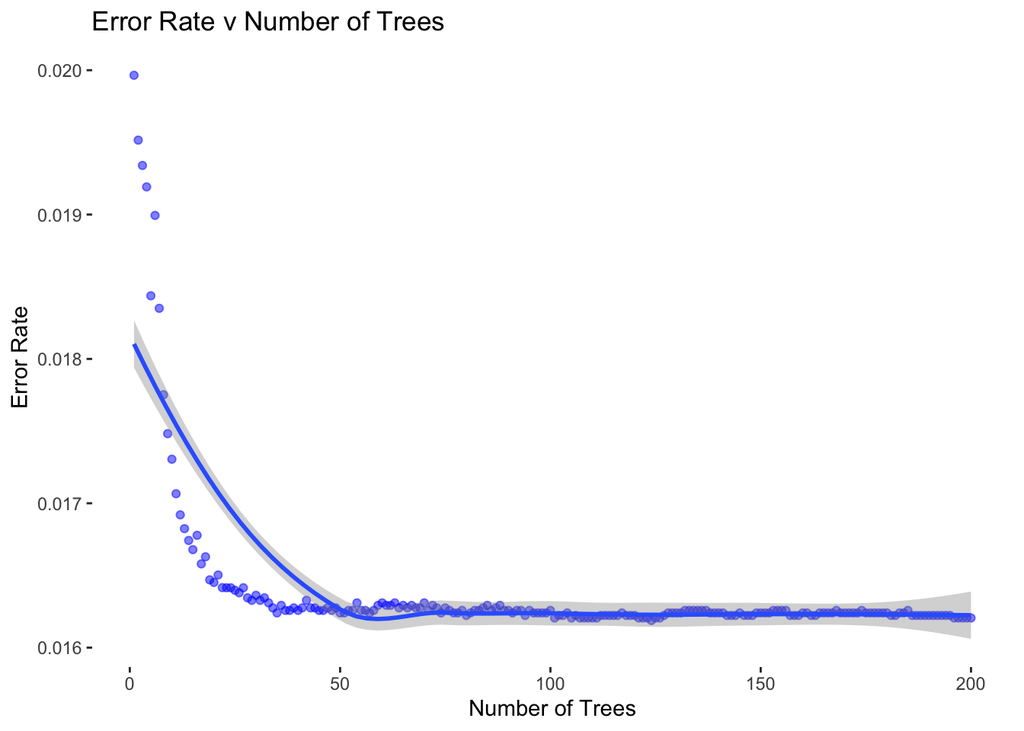

```r
oob_error <- bag_mod$err.rate[,1] # Extract oob error
plot_dat <- cbind.data.frame(rep(1:length(oob_error)), oob_error) # Create plot data
names(plot_dat) <- c("trees", "oob_error") # Name plot data

# Plot oob error
g_8 <- ggplot(plot_dat, aes(x = trees, y = oob_error)) + # Set x as trees and y as error
  geom_point(alpha = 0.5, color = "blue") + # Select geom point
  geom_smooth() + # Add smoothing line
  theme_bw() + # Set theme
  theme(panel.grid.major = element_blank(), # Remove grid
        panel.grid.minor = element_blank(), # Remove grid
        panel.border = element_blank(), # Remove grid
        panel.background = element_blank()) + # Remove grid
  labs(x = "Number of Trees", title = "Error Rate v Number of Trees",
       y = "Error Rate")  # Set labels
g_8 # Print plot
```

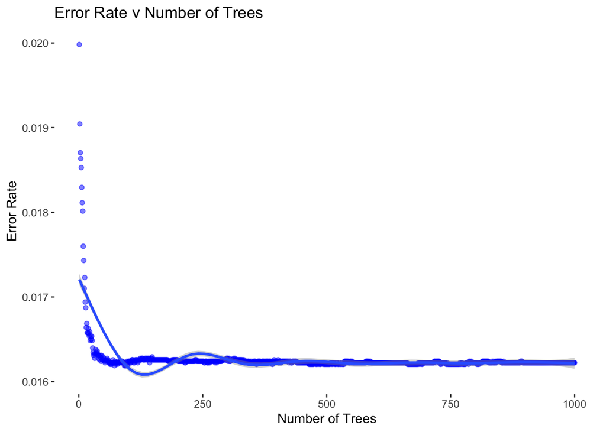

```r
bag_mod_2 <- randomForest(target ~., # Set tree formula
                data = over_data, # Set data to use
                mtry = 16, # Set number of variables to use
                ntree = 1000) # Set number of trees

oob_error <- bag_mod_2$err.rate[,1] # Extract oob error
plot_dat <- cbind.data.frame(rep(1:length(oob_error)), oob_error) # Create plot data
names(plot_dat) <- c("trees", "oob_error") # Name plot data

# Plot oob error
g_9 <- ggplot(plot_dat, aes(x = trees, y = oob_error)) + # Set x as trees and y as error
  geom_point(alpha = 0.5, color = "blue") + # Select geom point
  geom_smooth() + # Add smoothing line
  theme_bw() + # Set theme
  theme(panel.grid.major = element_blank(), # Remove grid
        panel.grid.minor = element_blank(), # Remove grid
        panel.border = element_blank(), # Remove grid
        panel.background = element_blank()) + # Remove grid
  labs(x = "Number of Trees", title = "Error Rate v Number of Trees",
       y = "Error Rate")  # Set labels
g_9 # Create plot
```

```r
bag_preds_2 <- predict(bag_mod_2, test_data) # Predict test data

t <- table(bag_preds_2,test_data$target) # Create table
confusionMatrix(t,  positive = "1") # Produce confusion matrix
```

```
## Confusion Matrix and Statistics
##
##
## bag_preds_2    0    1
##           0 6928   57
##           1  250   54
##
##                Accuracy : 0.9579
##                  95% CI : (0.953, 0.9624)
##     No Information Rate : 0.9848
##     P-Value [Acc > NIR] : 1
##
##                   Kappa : 0.2434
##
##  Mcnemar's Test P-Value : <2e-16
##
##             Sensitivity : 0.486486
##             Specificity : 0.965171
##          Pos Pred Value : 0.177632
##          Neg Pred Value : 0.991840
##              Prevalence : 0.015228
##          Detection Rate : 0.007408
##    Detection Prevalence : 0.041707
##       Balanced Accuracy : 0.725829
##
##        'Positive' Class : 1
##
```

```r
# Parameter tuning
trees <- c(10, 25, 50, 100, 200, 500, 1000) # Create vector of possible tree sizes
nodesize <- c(1, 10, 25, 50, 100, 200, 500, 1000) # Create vector of possible node sizes

params <- expand.grid(trees, nodesize) # Expand grid to get data frame of parameter combinations
names(params) <- c("trees", "nodesize") # Name parameter data frame
res_vec <- rep(NA, nrow(params)) # Create vector to store accuracy results

for(i in 1:nrow(params)){ # For each set of parameters
  set.seed(11111) # Set seed for reproducability
  mod <- randomForest(target ~. , # Set formula
                      data=over_data,# Set data
                      mtry = 16, # Set number of variables
                      importance = FALSE,  #
                      ntree = params$trees[i], # Set number of trees
                      nodesize = params$nodesize[i]) # Set node size
  res_vec[i] <- 1 - mod$err.rate[nrow(mod$err.rate),1] # Calculate out of bag accuracy
}
```

```r
summary(res_vec) # Summarize accuracy results
```

```
##    Min. 1st Qu.  Median    Mean 3rd Qu.    Max.
##  0.7645  0.9123  0.9769  0.9434  0.9837  0.9838
```

```r
res_db <- cbind.data.frame(params, res_vec) # Join parameters and accuracy results
names(res_db)[3] <- "oob_error" # Name accuracy results column
res_db # Print accuracy results column
```

```
##    trees nodesize oob_error
## 1     10        1 0.9826948
## 2     25        1 0.9836026
## 3     50        1 0.9837596
## 4    100        1 0.9837421
## 5    200        1 0.9837944
## 6    500        1 0.9837596
## 7   1000        1 0.9837770
## 8     10       10 0.9826948
## 9     25       10 0.9836026
## 10    50       10 0.9837596
## 11   100       10 0.9837421
## 12   200       10 0.9837944
## 13   500       10 0.9837596
## 14  1000       10 0.9837770
```

[output cut: 42 more lines]